# P4 Explore and Summarize Data: Red Wine EDA

### by Jason M. Medina

#### for Udacity Data Analyst Nanodegree (DAND)

## **Introduction**

##### This assignement explores the univariate, bivariate, & multivariate relationships between variables with data analysis techniques in R. The obersvation and variables have red wine samples only. The dataset is [here](https://www.google.com/url?q=https://s3.amazonaws.com/udacity-hosted-downloads/ud651/wineQualityReds.csv&sa=D&ust=1476736366367000&usg=AFQjCNFjTmiLhfLDU742qLGOWc_D6tZUrg); and [this information document](https://s3.amazonaws.com/udacity-hosted-downloads/ud651/wineQualityInfo.txt) contains helpful descriptions and domain knowledge for the dataset.

#### There are 1599 observations and 13 variables.

> ```
> ## 'data.frame':  1599 obs. of  13 variables:
> ##  $ X                   : int  1 2 3 4 5 6 7 8 9 10 ...
> ##  $ fixed.acidity       : num  7.4 7.8 7.8 11.2 7.4 7.4 7.9 7.3 7.8 7.5 ...
> ##  $ volatile.acidity    : num  0.7 0.88 0.76 0.28 0.7 0.66 0.6 0.65 0.58 0.5 ...
> ##  $ citric.acid         : num  0 0 0.04 0.56 0 0 0.06 0 0.02 0.36 ...
> ##  $ residual.sugar      : num  1.9 2.6 2.3 1.9 1.9 1.8 1.6 1.2 2 6.1 ...
> ##  $ chlorides           : num  0.076 0.098 0.092 0.075 0.076 0.075 0.069 0.065 0.073 0.071 ...
> ##  $ free.sulfur.dioxide : num  11 25 15 17 11 13 15 15 9 17 ...
> ##  $ total.sulfur.dioxide: num  34 67 54 60 34 40 59 21 18 102 ...
> ##  $ density             : num  0.998 0.997 0.997 0.998 0.998 ...
> ##  $ pH                  : num  3.51 3.2 3.26 3.16 3.51 3.51 3.3 3.39 3.36 3.35 ...
> ##  $ sulphates           : num  0.56 0.68 0.65 0.58 0.56 0.56 0.46 0.47 0.57 0.8 ...
> ##  $ alcohol             : num  9.4 9.8 9.8 9.8 9.4 9.4 9.4 10 9.5 10.5 ...
> ##  $ quality             : int  5 5 5 6 5 5 5 7 7 5 ...
> ```

> * X, the first variable, looks like a unique identifier. * Quality is an ordinal categorical variable. A new variable is created from quality for subsquent analysis. [Read this](https://statistics.laerd.com/statistical-guides/types-of-variable.php) for more on types of variables. + From the information document: “The inputs include objective tests (e.g. PH values) and the output is based on sensory data (median of at least 3 evaluations made by wine experts). Each expert graded the wine quality between 0 (very bad) and 10 (very excellent)”. Nota bene no observations have a quality greater than 8. This lack of disparity is not favorable for feature analysis. * Except for *total.sulfar.dioxide* and *free.sulfar.dioxide*, all other numeric variables are continous. * Note *total.sulfer.dioxide* is the sum of _free.sulfur.dioxid__ and bound forms; hence the two sulfur variables are related.  
> * *volitale.acidity* is different from *fixed.acidity* and *citric.acid*.

## **Univariate Plots Section**

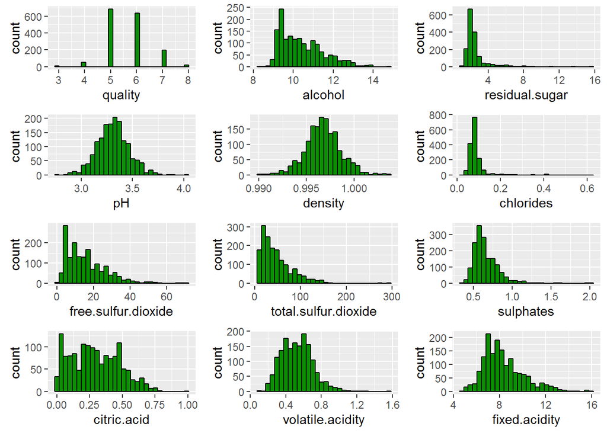

## **Univariate Analysis**

###### **This summary excludes the unique identifer variable X**:

> ```
> ##  fixed.acidity   volatile.acidity  citric.acid    residual.sugar
> ##  Min.   : 4.60   Min.   :0.1200   Min.   :0.000   Min.   : 0.900
> ##  1st Qu.: 7.10   1st Qu.:0.3900   1st Qu.:0.090   1st Qu.: 1.900
> ##  Median : 7.90   Median :0.5200   Median :0.260   Median : 2.200
> ##  Mean   : 8.32   Mean   :0.5278   Mean   :0.271   Mean   : 2.539
> ##  3rd Qu.: 9.20   3rd Qu.:0.6400   3rd Qu.:0.420   3rd Qu.: 2.600
> ##  Max.   :15.90   Max.   :1.5800   Max.   :1.000   Max.   :15.500
> ##    chlorides       free.sulfur.dioxide total.sulfur.dioxide
> ##  Min.   :0.01200   Min.   : 1.00       Min.   :  6.00
> ##  1st Qu.:0.07000   1st Qu.: 7.00       1st Qu.: 22.00
> ##  Median :0.07900   Median :14.00       Median : 38.00
> ##  Mean   :0.08747   Mean   :15.87       Mean   : 46.47
> ##  3rd Qu.:0.09000   3rd Qu.:21.00       3rd Qu.: 62.00
> ##  Max.   :0.61100   Max.   :72.00       Max.   :289.00
> ##     density             pH          sulphates         alcohol
> ##  Min.   :0.9901   Min.   :2.740   Min.   :0.3300   Min.   : 8.40
> ##  1st Qu.:0.9956   1st Qu.:3.210   1st Qu.:0.5500   1st Qu.: 9.50
> ##  Median :0.9968   Median :3.310   Median :0.6200   Median :10.20
> ##  Mean   :0.9967   Mean   :3.311   Mean   :0.6581   Mean   :10.42
> ##  3rd Qu.:0.9978   3rd Qu.:3.400   3rd Qu.:0.7300   3rd Qu.:11.10
> ##  Max.   :1.0037   Max.   :4.010   Max.   :2.0000   Max.   :14.90
> ##     quality
> ##  Min.   :3.000
> ##  1st Qu.:5.000
> ##  Median :6.000
> ##  Mean   :5.636
> ##  3rd Qu.:6.000
> ##  Max.   :8.000
> ```

> Quality variable max is 8 with a 6 median and 5.6 mean. Recall quality is on a 0 to 10 scale; hence both end points, zero and ten, are missing as is nine as seen in histogram.

> Citric acid min is 0. There exist 132 zero values. Only variable with any zero values.

> Residual sugar, chlorides and sulfurs appear to have outliers.

> Similar max for fixed acidity, residual sugar and alcohol but different means and medians.

> Density and pH appear to have normal distributions.

#### Quality variable

> The feature of main interest is *quality* categorical numeric, ordinal variable. Observations rate into three groups like bad, average or good with respect to this variable. Although it is not possible to place a value nor say an average wine is three times better than a bad wine.

#### Citric acid as a supplement, some wines have no citric acid

> There exist 132 zero values in the citric acid variable. These zeros account for 8.3 percent. Citric acid is an inexpensive way to boost total acidity in wine. [This wiki link](https://en.wikipedia.org/wiki/Acids_in_wine#Citric_acid) says the use of citric acid for acidification is prohibited in the EU; though limited use is permitted for removing excess iron and copper from wine if potassium ferrocyanide is unavailable.

#### More normal distribution log10 scale for fixed & volatile acidity

> Plotting the fixed and volatile acidity on log10 scale yields a more normal distribution.

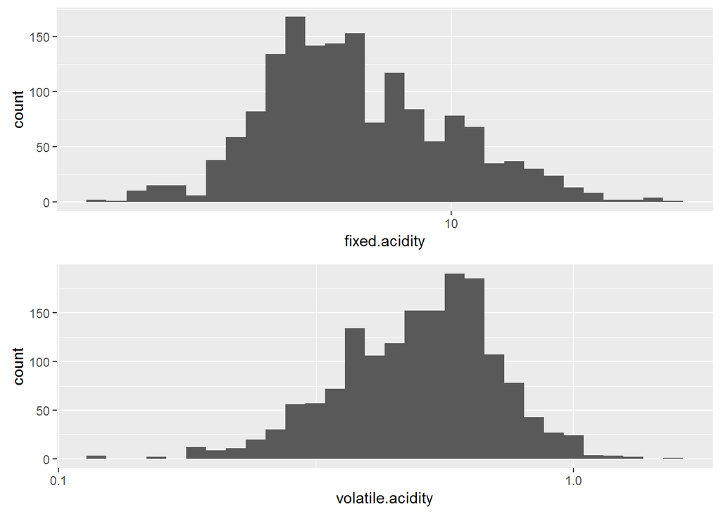

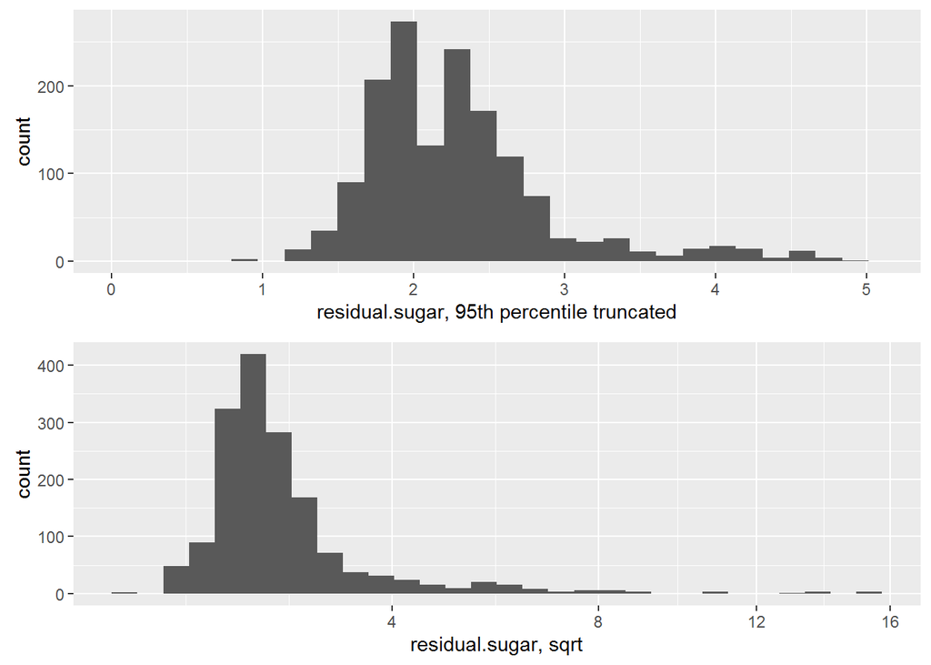

## **Template questions**

### *What other features in the dataset do you think will help support your investigation into your feature(s) of interest?*

> There may exist an association between residual.sugar and quality. Unsure how the multiple acidity variables relate to each other and quality. Citric.acid is the only variable with observations equal zero. Expect most positive correlation for quality to be with alcohol, and most negative to be volatile acid.

### *Did you create any new variables from existing variables in the dataset?*

> Yes, changed quality to an ordered factor the created a new variable called rating to bucket wines as bad, average or good based on quality. In addition, the tt.acidity variable sums up fixed acidity, volatile acidity, and citric acid as these acids are independent. Volatile acidity or acetic acid at high levels can lead to an unpleasant vinegar taste. Therefore expect at least a moderate negative correlation between volatile acidity and quality. On the other hand, citric acid in small quantities can add ‘freshness’ and flavor to wines while fixed acids do not evaporate readily per the information document.

```r
# change quality to ordered factor
rw$quality <- factor(rw$quality, ordered = TRUE)

# create total acidity variable
rw$ttl.acidity <- rw$citric.acid + rw$fixed.acidity + rw$volatile.acidity

# create rating variable wrt quality
rw$rating <- ifelse(rw$quality < 5, 'bad', ifelse(
  rw$quality < 7, 'average', 'good'))
rw$rating <- ordered(rw$rating,
                     levels = c('bad', 'average', 'good'))
```

> Summary for rating variable below, not many bad or good wines in the dataset limits model learning and training.

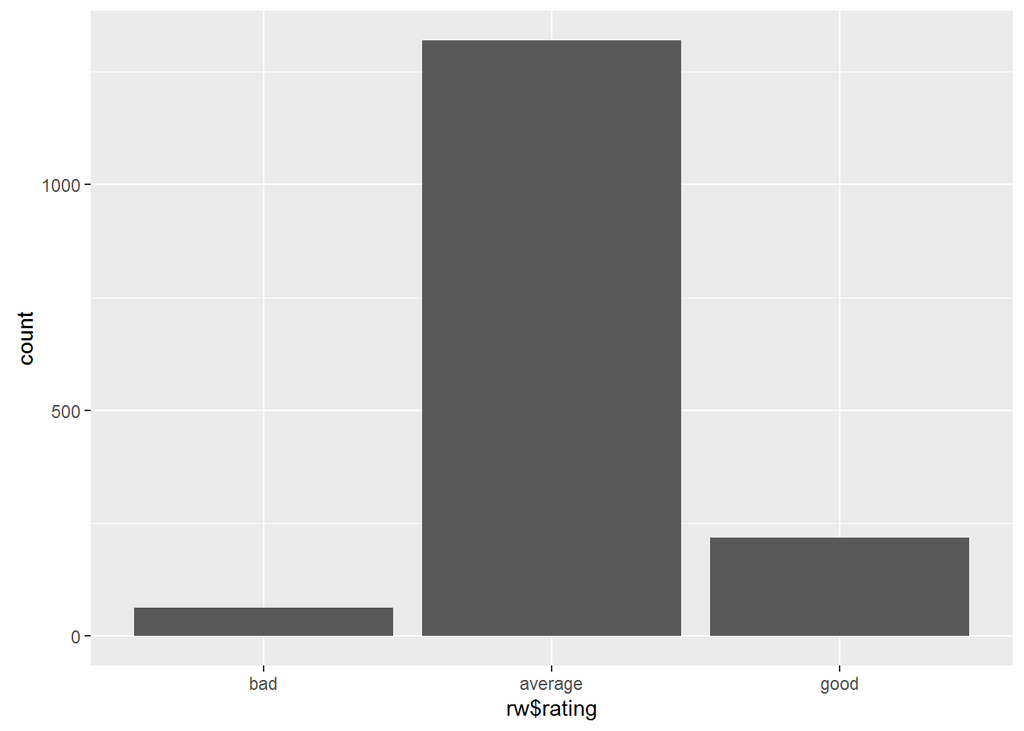

```
##     bad average    good
##       4      82      14
```

### *Of the features you investigated, were there any unusual distributions? Did you perform any operations on the data to tidy, adjust, or change the form of the data? If so, why did you do this?*

> Tidy adjustments not made to data. The lack of disparity in the distribution for quality standsout. Other variables have long tails, see above sections for additional commentary. Subsquent boxplots to show outliers while ratings feature to help classify observations in further analysis.

# Bivariate Plots Section

###### *(Recall .6 to .79 corr is strong, .4 to .59 moderate and less than .2 is very weak)*

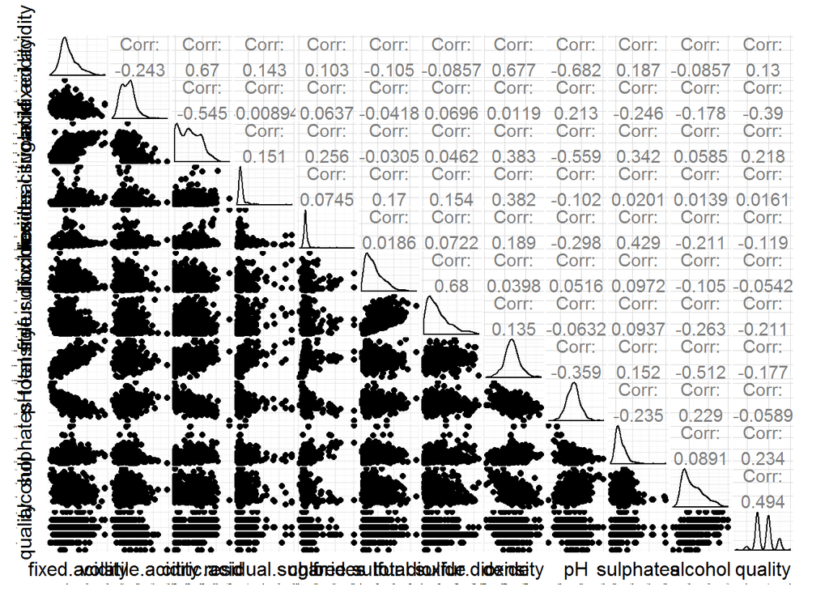

```
##
## ---------------------------------------------------------------------------
##           &nbsp;            fixed.acidity   volatile.acidity   citric.acid
## -------------------------- --------------- ------------------ -------------
##     **fixed.acidity**             1             -0.2561        **0.6717**
##
##    **volatile.acidity**        -0.2561             1           **-0.5525**
##
##      **citric.acid**         **0.6717**       **-0.5525**           1
##
##     **residual.sugar**         0.1148           0.001918         0.1436
##
##       **chlorides**            0.09371           0.0613          0.2038
##
##  **free.sulfur.dioxide**       -0.1538          -0.0105         -0.06098
##
##  **total.sulfur.dioxide**      -0.1132          0.07647          0.03553
##
##        **density**            **0.668**         0.02203        **0.3649**
##
##           **pH**             **-0.683**          0.2349        **-0.5419**
##
##       **sulphates**             0.183            -0.261        **0.3128**
##
##        **alcohol**            -0.06167          -0.2023          0.1099
##
##        **quality**             0.1241         **-0.3906**        0.2264
##
##      **ttl.acidity**         **0.9964**         -0.2044        **0.6904**
## ---------------------------------------------------------------------------
##
## Table: Table continues below
##
##
## -----------------------------------------------------------------------------
##           &nbsp;            residual.sugar   chlorides   free.sulfur.dioxide
## -------------------------- ---------------- ----------- ---------------------
##     **fixed.acidity**           0.1148        0.09371          -0.1538
##
##    **volatile.acidity**        0.001918       0.0613           -0.0105
```

[output cut: 74 more lines]

```
##
##  **total.sulfur.dioxide**    0.04295     -0.2057     -0.1851     -0.09628
##
##        **density**           0.1485    **-0.4962**   -0.1749    **0.6756**
##
##           **pH**             -0.1966     0.2056     -0.05773    **-0.6835**
##
##       **sulphates**             1        0.09359     0.2514       0.1816
##
##        **alcohol**           0.09359        1      **0.4762**    -0.06667
##
##        **quality**           0.2514    **0.4762**       1         0.1038
##
##      **ttl.acidity**         0.1816     -0.06667     0.1038          1
## ----------------------------------------------------------------------------
```

# Bivariate Analysis

### *Talk about some of the relationships you observed in this part of the investigation. How did the feature(s) of interest vary with other features in the dataset?*

> - Two variables, alcohol and volatile acidity have moderate correlations with quality. There is a 0.48 moderate positive correlation with alcohol and and quality. From the plot, quality increases at moderate rates with higher alcohol.

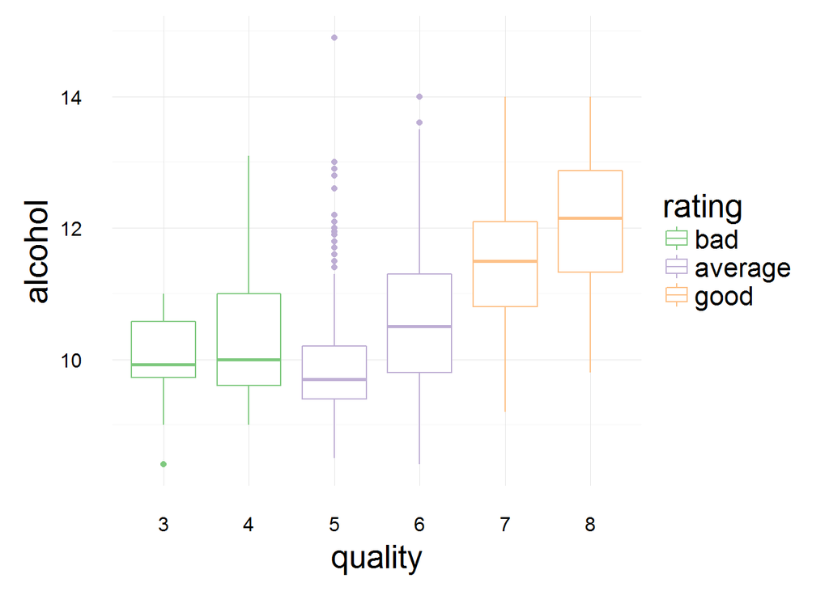

````
```
## # A tibble: 3 x 4
##    rating alcohol_mean alcohol_median     n
##     <ord>        <dbl>          <dbl> <int>
## 1     bad     10.21587           10.0    63
## 2 average     10.25272           10.0  1319
## 3    good     11.51805           11.6   217
```
````

> - Volatile acid and quality have a -0.39 moderate negative correlation, which implies red wine quality decreases as volatile acidity increases.

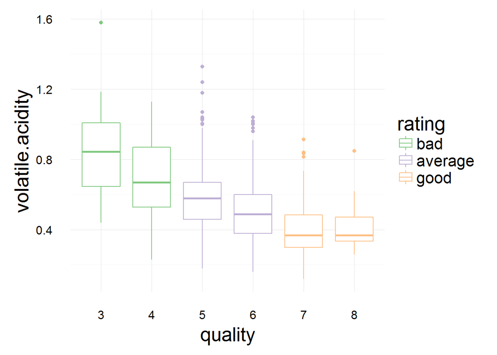

```
## # A tibble: 3 x 4
##    rating volatile.acidity_mean volatile.acidity_median     n
##     <ord>                 <dbl>                   <dbl> <int>
## 1     bad             0.7242063                    0.68    63
## 2 average             0.5385595                    0.54  1319
## 3    good             0.4055300                    0.37   217
```

> - There exist weak positive correlations for both 1) quality and sulphates and 2) quality and citric acid. Quality trends in the same direction as both sulphates and citric acid at a weak rate.

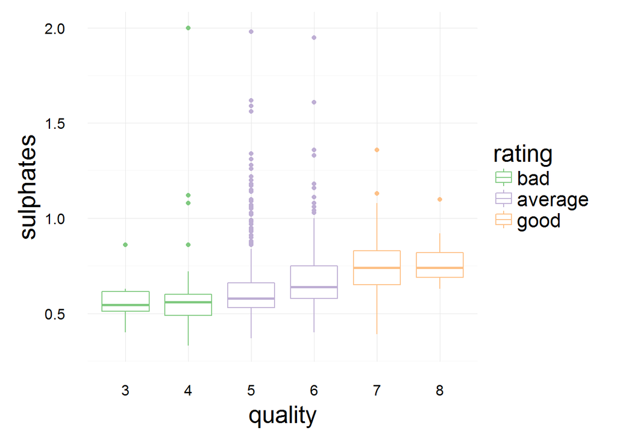

```
## # A tibble: 3 x 4
##    rating sulphates_mean sulphates_median     n
##     <ord>          <dbl>            <dbl> <int>
## 1     bad      0.5922222             0.56    63
## 2 average      0.6472631             0.61  1319
## 3    good      0.7434562             0.74   217
```

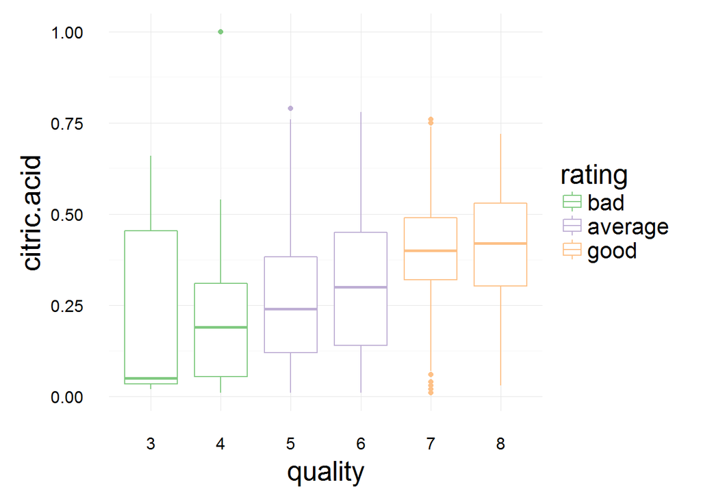

```
## # A tibble: 3 x 4
##    rating citric.acid_mean citric.acid_median     n
##     <ord>            <dbl>              <dbl> <int>
## 1     bad        0.1736508               0.08    63
## 2 average        0.2582638               0.24  1319
## 3    good        0.3764977               0.40   217
```

> - Citric acid and fixed acidity have a strong positive correlation of 0.67; citric acid has a weak positive correlation of 0.23 with quality while fixed acidity has a very weak positive correlation of 0.12.

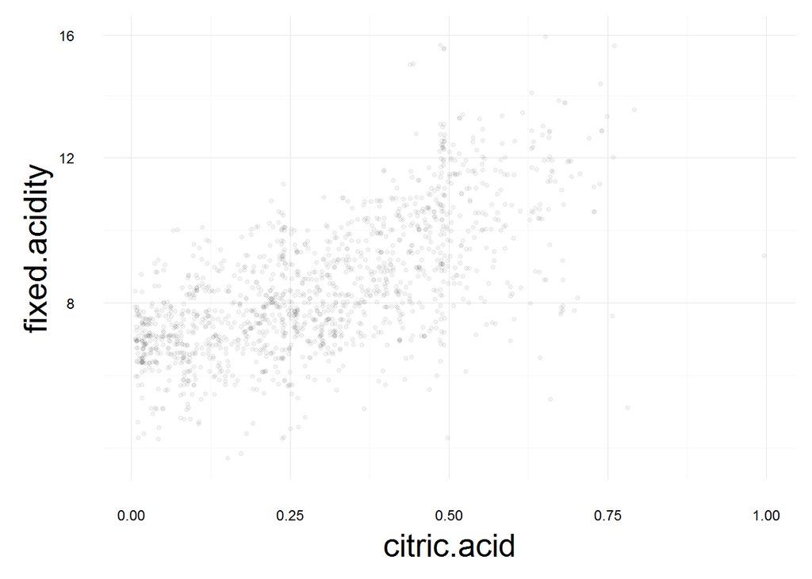

```
## # A tibble: 3 x 4
##    rating fixed.acidity_mean fixed.acidity_median     n
##     <ord>              <dbl>                <dbl> <int>
## 1     bad           7.871429                  7.5    63
## 2 average           8.254284                  7.8  1319
## 3    good           8.847005                  8.7   217
```

> - The moderate negative correlation volatile acidity and citric acid where the volatile acidity y values scale with the squre root function.

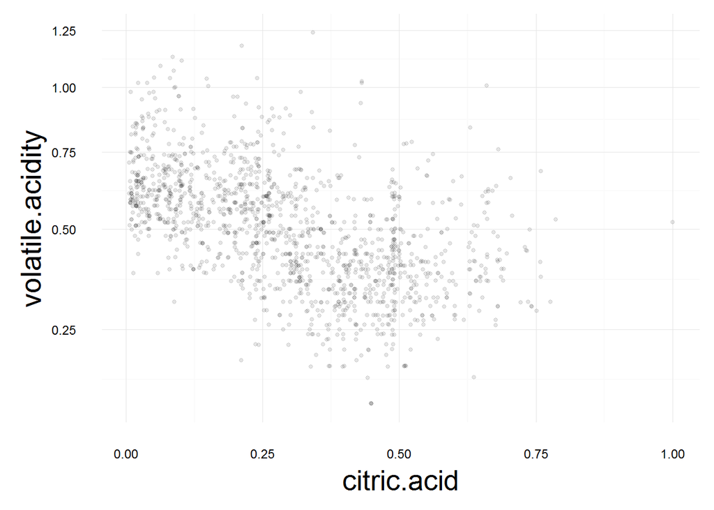

```
## # A tibble: 3 x 4
##    rating volatile.acidity_mean volatile.acidity_median     n
##     <ord>                 <dbl>                   <dbl> <int>
## 1     bad             0.7242063                    0.68    63
## 2 average             0.5385595                    0.54  1319
## 3    good             0.4055300                    0.37   217
```

## Other observations and noteable correlations

> *ttl.acidity* variable is the sum of citric, volatile and fixed acidity. Ignore any correlation efficents between these three variable.

> Citric acid and sulfates have weak positive correlations with quality.

> Residual sugar corellates to only one variable, density.

> Density and citric acid each correlate with five variables.

> Not unexpected, fixed.acidity and pH have a strong negative correlation, likewise, total.sulfur.dioxide and free.sulfur.dioxide have a strong positive correlation. A list of notable correlations is below.

Notable positive correlations (i.e. > 0.3)

- 0.672 fixed.acidity & citric.acid (strong)
- 0.668 fixed.acidity & density (strong)
- 0.668 free.sulfur.dioxide & total.sulfur.dioxide (strong)
- 0.476 alcohol & quality (moderate)
- 0.371 chlorides & sulphates (weak)
- 0.365 citric.acid & density (weak)
- 0.356 residual.sugar & density (weak)
- 0.313 citric.acid & sulphates (weak)

Noteable negative correlations i.e. < -0.3)

- -0.683 fixed.acidity & pH (strong)
- -0.553 volatile.acidity & citric.acid (moderate)
- -0.542 pH & citric.acid (moderate)
- -0.496 density & alcohol (moderate)
- -0.391 volatile.acidity & quality (weak)

## **Template questions**

### *Did you observe any interesting relationships between the other features (not the main feature(s) of interest)?*

> Yes, [the Simpsons package](https://mran.microsoft.com/web/packages/Simpsons/Simpsons.pdf) clusters data into subsets to test if the regression at the level of the group is in the opposite direction at the level of the clusters. This package helps identify instances of Simpsons paradox.

```r
simpson <- Simpsons(citric.acid, fixed.acidity, data = rw)
```

[output not shown]

```r
simpson <- Simpsons(density, fixed.acidity, data = rw)
```

[output not shown]

## *Multivariate Plots Section*

> There is a negative moderate correlation of 0.5 between alcohol and density. This means higher alcohol implies lower density. This makes sense since alcohol is less dense than water. The boxplot confirms wines rated good have higher alcohol content.

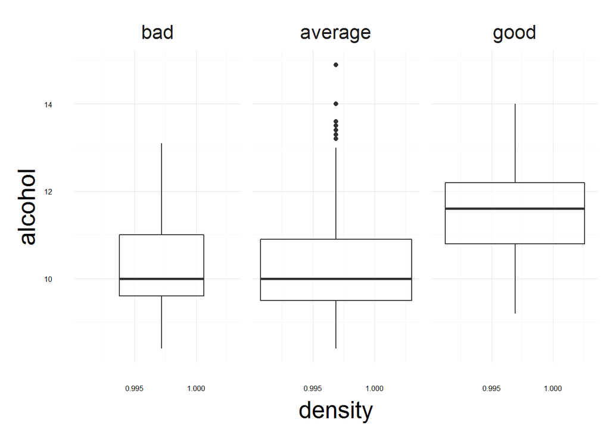

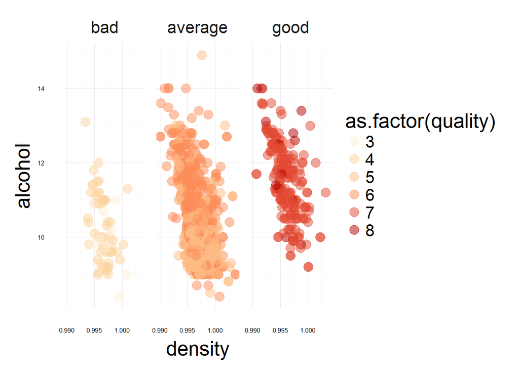

> pH measures acidity, this multivariate plot shows the negative correlations between pH and fixed acidty has little affect on rating.

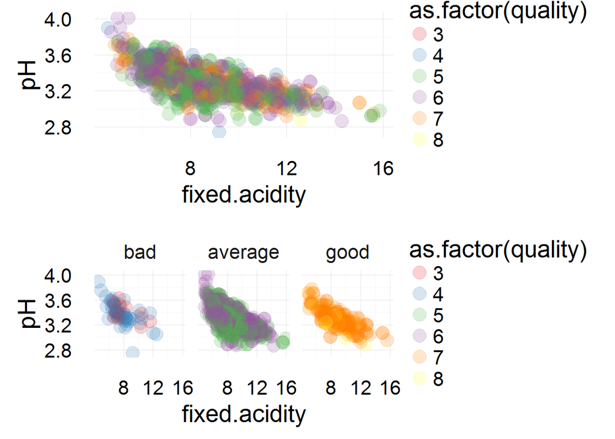

> Alcohol has a moderate positive correlation with quality while sulphates has a weak positive correlation. Sulphates is on a log scale.

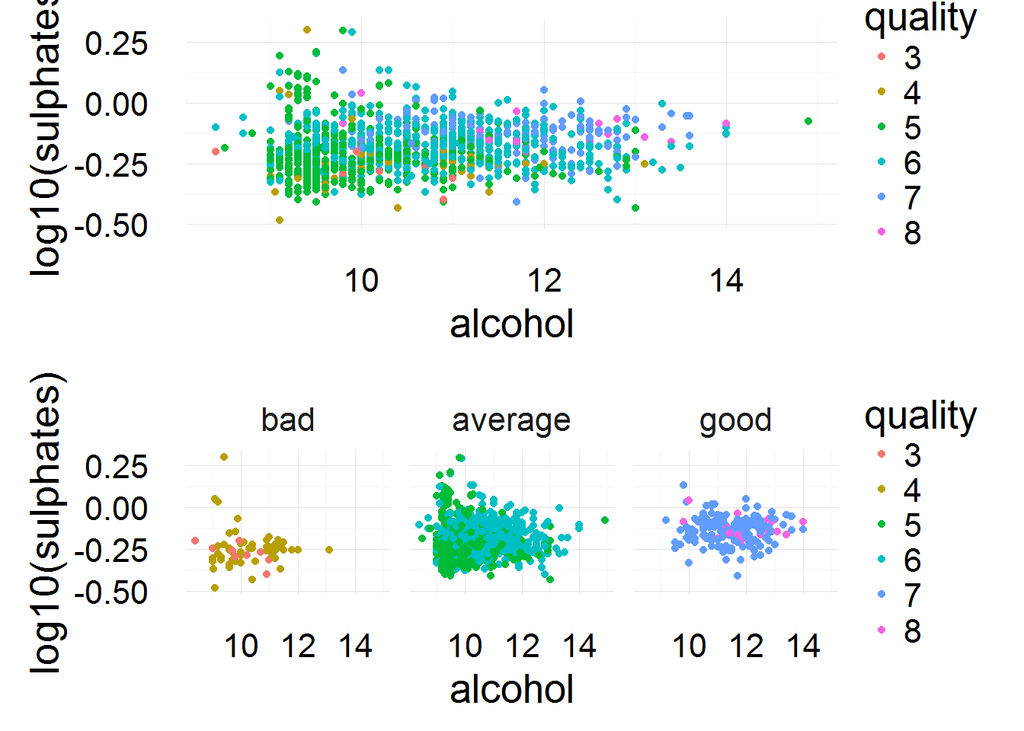

## *Multivariate Analysis*

> Alcohol, sulphates and citric acid have the largest positive correlations with quality. Higher quality wines tend to be higher in alcohol, citric acid and sulphates. On the other hand, higher quality wines tend to be lower in volatile acidity.

### Talk about some of the relationships you observed in this part of the investigation. Were there features that strengthened each other in terms of looking at your feature(s) of interest?

> Applying the simpsons package to different variables to identify lurking variables impacting the overall coefficent variables. Residual sugar and pH had no meaningful correlation; this confirms that wine quality really is about acidic profiles.

### Were there any interesting or surprising interactions between features?

> There is no meaningful correlation between residual sugar and alcohol; that and the positive correlation between pH & volatile acidity were unexpected.

### OPTIONAL: Did you create any models with your dataset? Discuss the strengths and limitations of your model.

```r
m <- lm(pH ~
            I(log10(fixed.acidity)) +
            I(log10(volatile.acidity)) +
            I(log10(citric.acid)),
                data = subset(rw, rw$citric.acid > 0))

rw$pH.predictions <- predict(m,rw)
rw$pH.error <- (rw$pH.predictions - rw$pH)/rw$pH

ggplot(data = df, aes(x = quality, y = pH.error)) +
  geom_boxplot()
summary(m)
```

[output not shown]

# Final Plots and Summary

### Plot One: Alcohol and Wine Quality

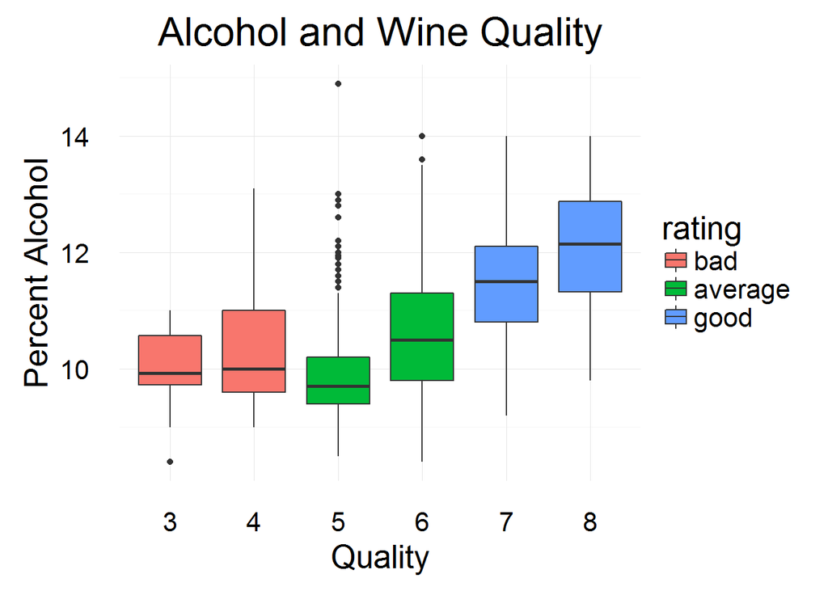

### *Description One*

> This boxplot confirms wine quality increases with alcohol content. This is similar an early chart, except this chart uses rating variable to fill instead of color boxplots.

### Plot Two: Acidic and pH variable

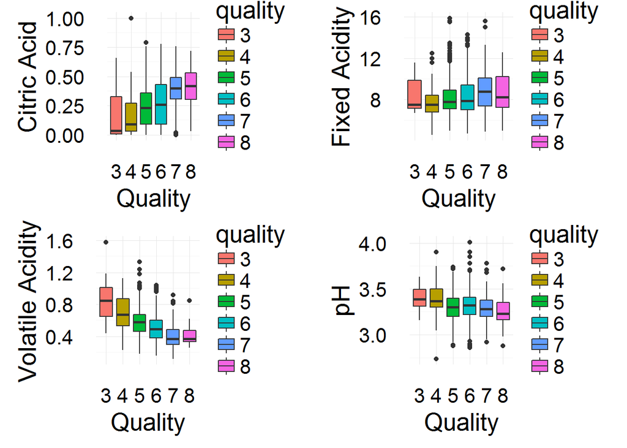

### *Description Two*

> These boxplots show the positive and negative correlations for the three acidic variables and one pH variable. Lower quality wines tend to have higher values for pH and Volatile acid. Higher quality wines have more citric acid; however there are a number of outliers rated average with high fixed acidity. Higher fixed acidity and quality have a very weak correlation.

### Plot Three

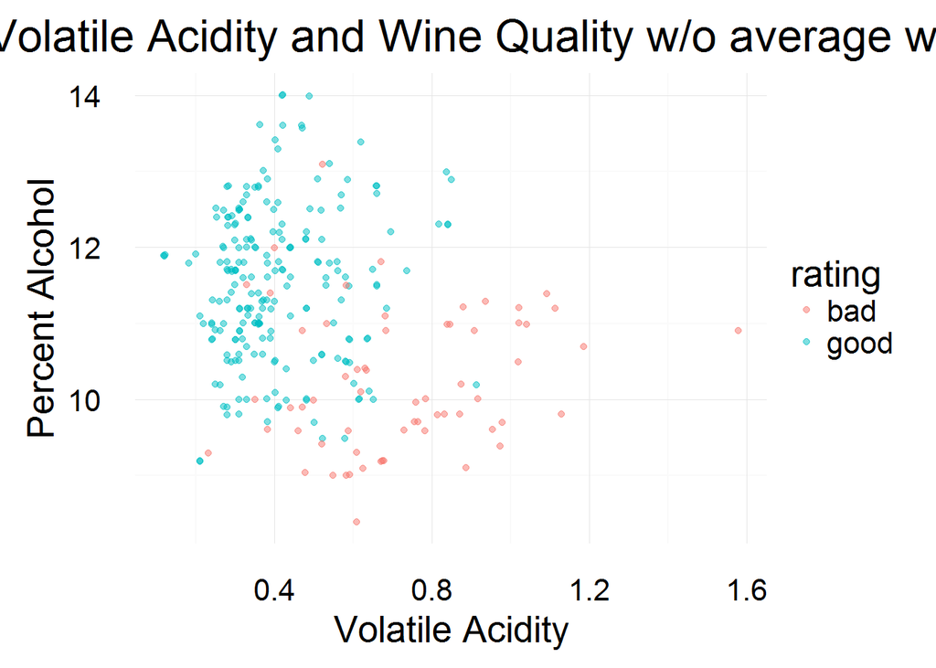

# Reflection

“The combination of some data and an aching desire for an answer does not ensure that a reasonable answer can be extracted from a given body of data.” *- John Tukey*

#### Histogram counts stack up at 5 & 6. Table shows 83% of values are rated 5 or 6. Note this lack of disparity could impact the analysis or multivariate models. The proportion of quality variables are tabled below the plot.

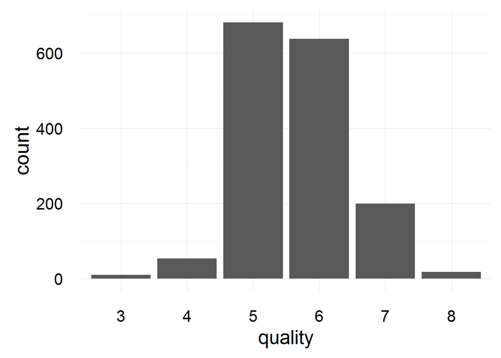

```
##   3   4   5   6   7   8
##   1   3  43  40  12   1 100
```

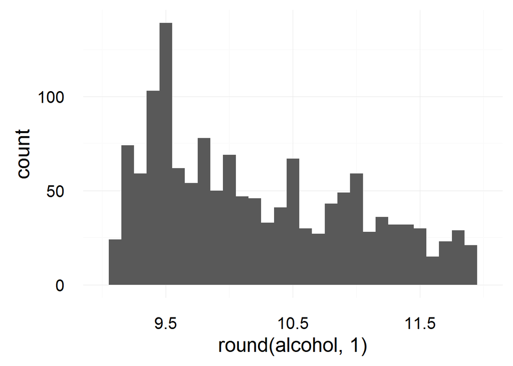

```
##
##  9.5  9.4  9.8  9.2   10 10.5  9.6  9.3   11  9.7
##  139  103   78   74   69   67   62   59   59   54
```

```
##
## 13.3 13.4  8.4  8.7  8.8 13.1  8.5 13.2 13.5 14.9
##    3    3    2    2    2    2    1    1    1    1
```

```
##   8   9  10  11  12  13  14  15
##   0  18  43  21  13   4   1   0 100
```

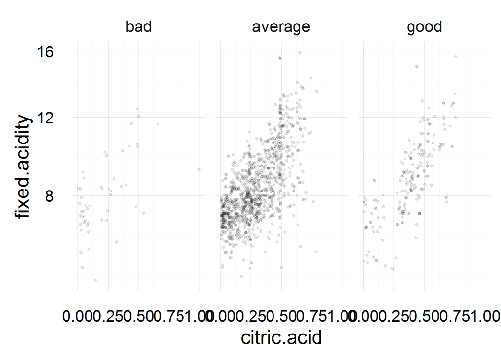

[output not shown]

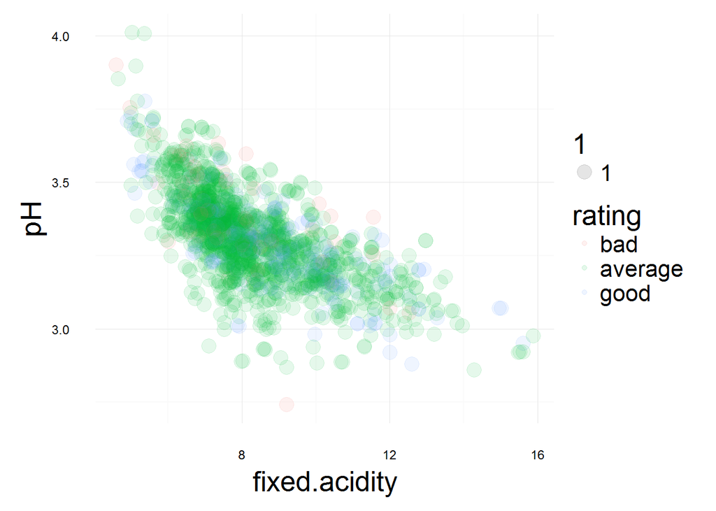

```
## # A tibble: 3 x 4
##    rating  pH_mean pH_median     n
##     <ord>    <dbl>     <dbl> <int>
## 1     bad 3.384127      3.38    63
## 2 average 3.311296      3.31  1319
## 3    good 3.288802      3.27   217
```

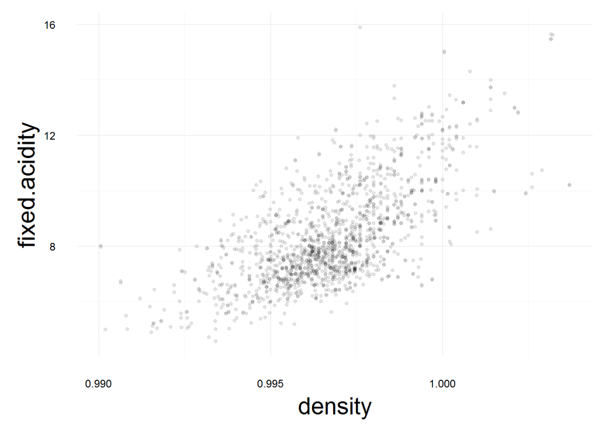

```
## # A tibble: 3 x 4
##    rating fixed.acidity_mean fixed.acidity_median     n
##     <ord>              <dbl>                <dbl> <int>
## 1     bad           7.871429                  7.5    63
## 2 average           8.254284                  7.8  1319
## 3    good           8.847005                  8.7   217
```

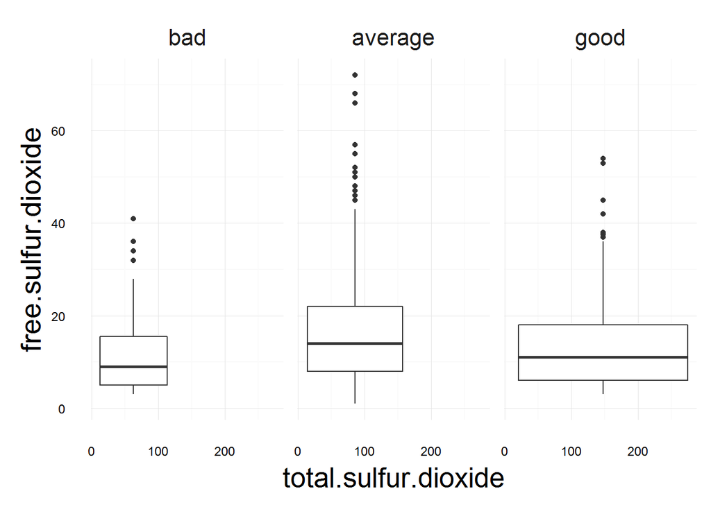

```
## # A tibble: 3 x 4
##    rating free.sulfur.dioxide_mean free.sulfur.dioxide_median     n
##     <ord>                    <dbl>                      <dbl> <int>
## 1     bad                 12.06349                          9    63
## 2 average                 16.36846                         14  1319
## 3    good                 13.98157                         11   217
```

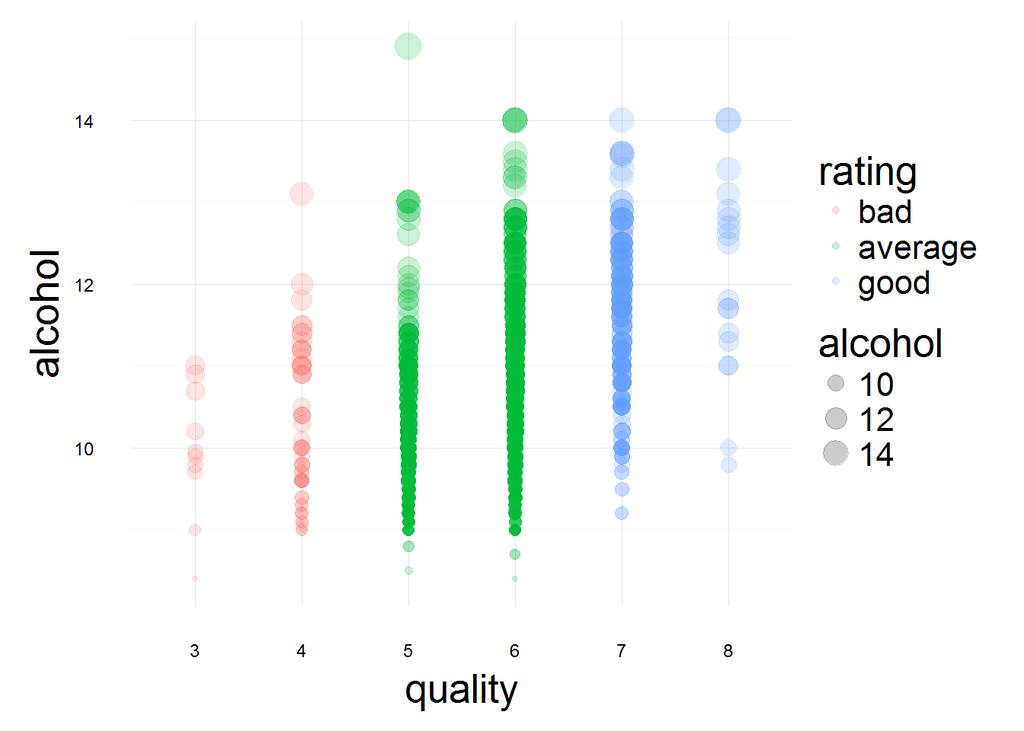

```
## # A tibble: 3 x 4
##    rating alcohol_mean alcohol_median     n
##     <ord>        <dbl>          <dbl> <int>
## 1     bad     10.21587           10.0    63
## 2 average     10.25272           10.0  1319
## 3    good     11.51805           11.6   217
```

### What is the structure of your dataset?

> There are thireteen variables with 1,599 observations. Quality is the categorical variable. The X variable is a row id, and the other variables are numeric with only citric.acid touching 0, that is every continous variable except for citric.acid is strictly greater than zero.